# RED WINE QUALITY EXPLORATION by FELIPE BARROS

# Multivariate Plots Section

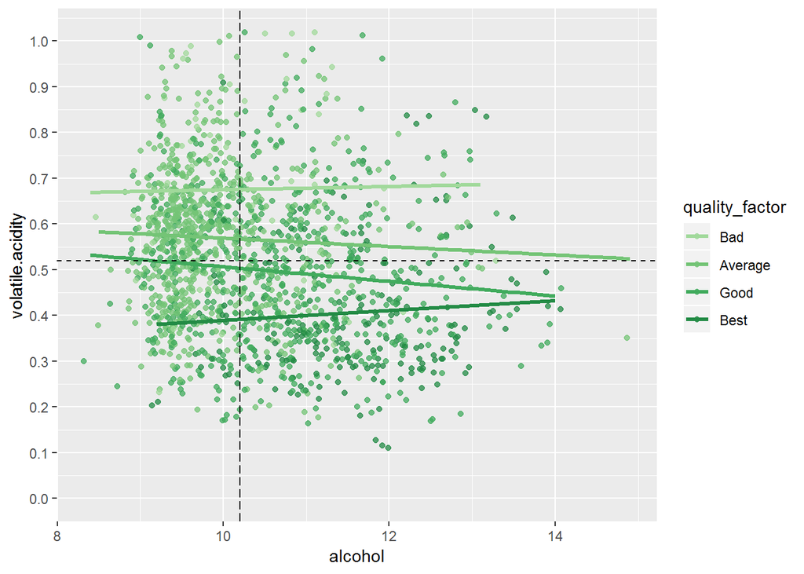

The top 1% values for volatile acidity were removed on this plot. The vertical and horizontal lines are the medians for alcohol and volatile acidity, respectively. By using both lines, the graph is divided into four quadrants. We can see how alcohol has a higher influence in the quality factor as most of bad and average wines are on the second or third quadrants, where alcohol levels are lower. The first quadrant has a good number of good wines but also has some presence of bad and average wines. The fourth quadrant, where alcohol is high and volatile acidity is low is the best quadrant, as expected: most best wines are present there.

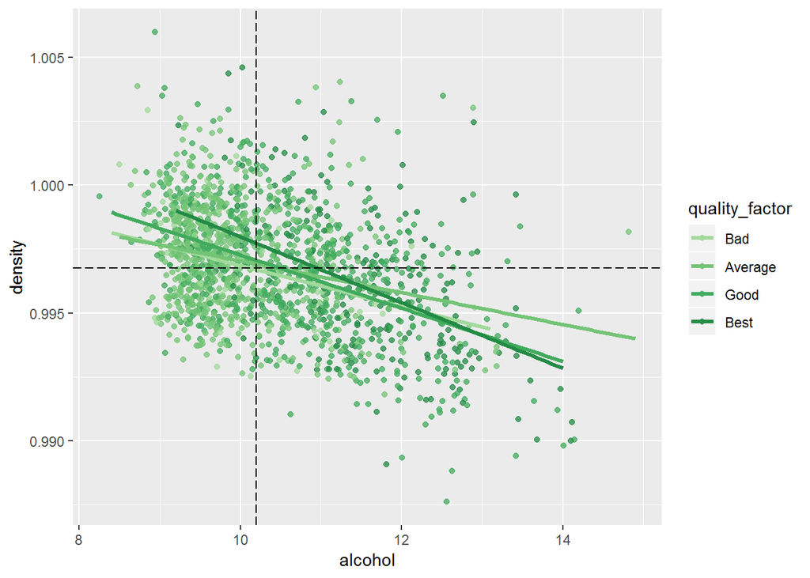

By swaping volatile acidity for density on the y-axis, the pattern is similar, but with even more bias towards the x-axis (alcohol). The vertical line (the median for alcohol) seems to be the only one dividing most of the good ones from the bad ones. This again goes against common knowledge that density is a good feature for telling the quality of a wine.

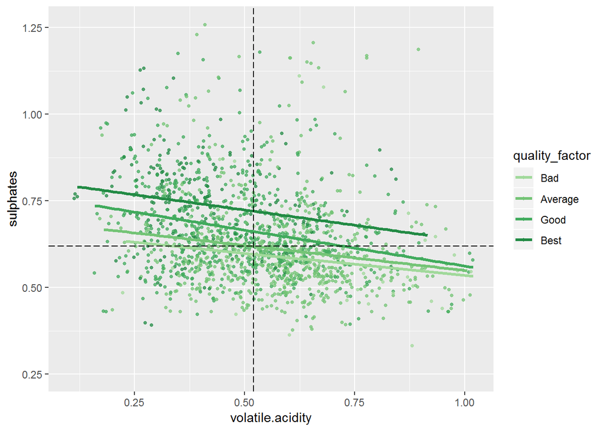

This plot also has a difference between the quadrants. In this case, the second quadrant (high sulphates and low volatile acidity) is where most of the best wines are.

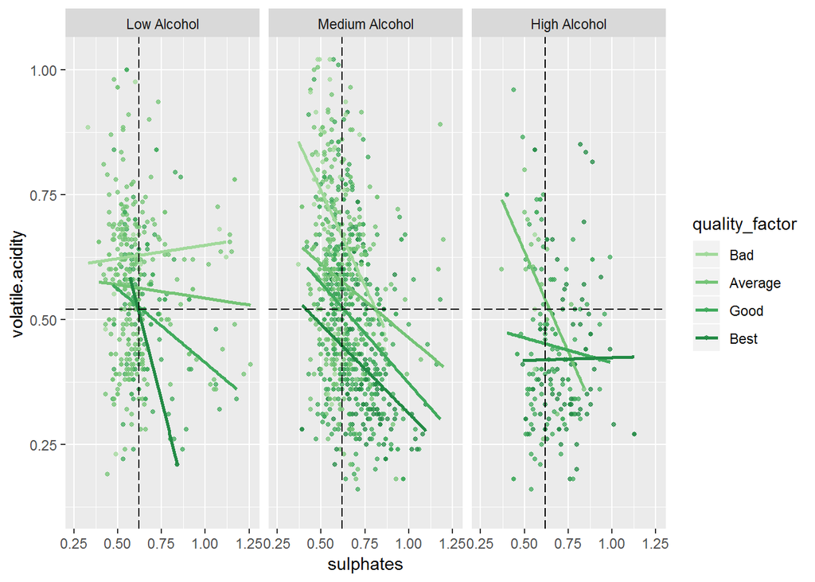

The top 1% for both axes were removed for this plot, in order to better visualize it. By dividing the alcohol levels into buckets, we can see not only how the quality of the wines are distributed in the buckets but also the distrubution of sulphates and volatile acidity. The high alcohol bucket has almost only good and best wines and most of the observations are on the fourth quadrant. On the opposite side, the low alcohol bucket has almost only average wines and most of the observations are on the second and third quadrants. The plot depicts at the same time the influence of the three features most impactful on the quality of a wine.

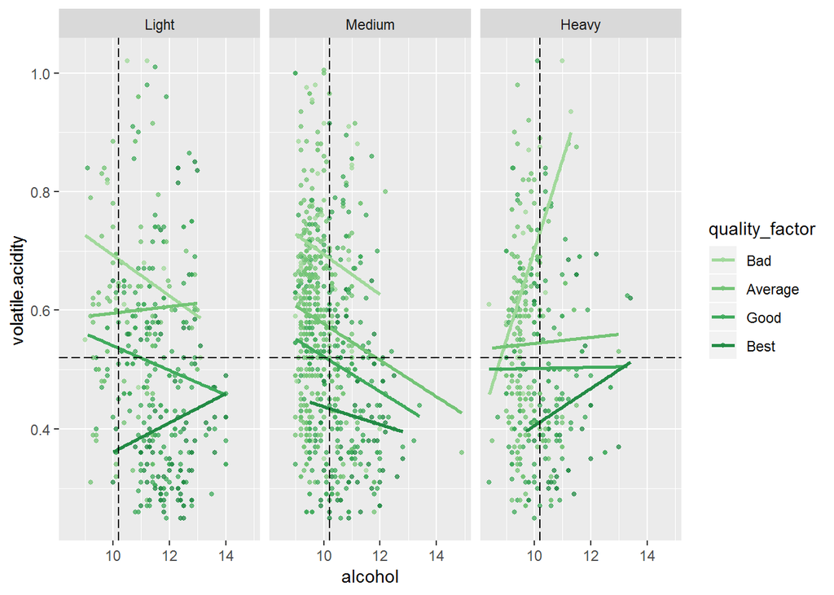

Lower density levels are correlated with better wine. In the low density bucket, most of the wines are good or best, as expected. They also are higher on alcohol levels. The medium density bucket is a surprise, as it has a more dense cloud of average wines than the high density bucket.

# Multivariate Analysis

By looking simultaneously at several features and their relationship with quality, it was possible to see how each other contribute to the quality of the wine. Since the three best features to try to predict the quality of the wine are alcohol, volatile acidity and sulphates, creating a plot with the relationship between them and quality efficiently described the properties of a good wine.

To improve the analysis, I decided to divide quality, alcohol and density into buckets. That allowed me to visualize multiple features interacting with each other at the same time.

A surprising interaction was found when density values were cut into buckets. Even though a linear regression model suggests that low density levels are correlated with better wine, the middle bucket seemed worst than the heavy bucket.

# Final Plots and Summary

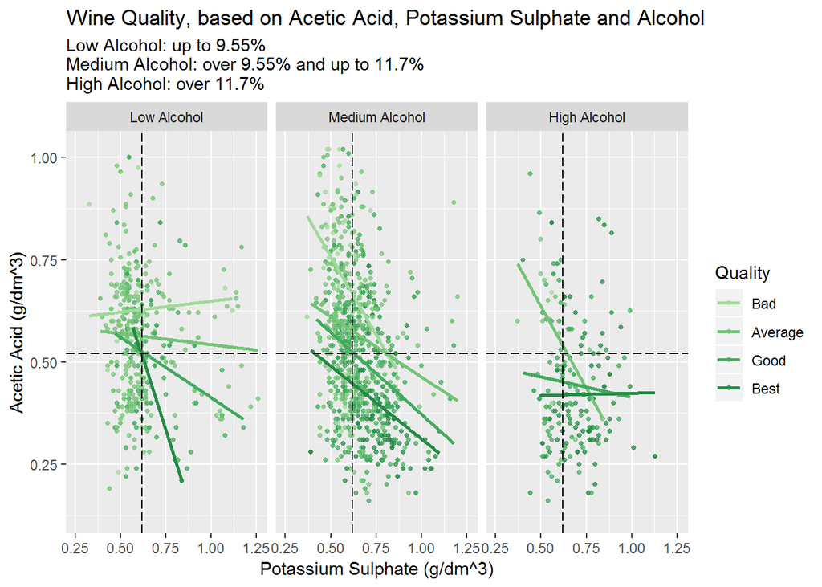

This is the best plot to represent the dataset. We can see how alcohol heavily influences the quality of the wine by the difference of observations on each bucket. The median lines for Acetic Acid and Potassium Sulphate also help to illustrate how these features work in relation to the quality of the wine. More acetic acid gives a vinegar taste to the wine, so most wines above the horizontal line are Bad or Average. Potassium Sulphate helps with antimicrobial and antioxidant effects on wine, giving them an overall better quality. Because of that, wines on the right of the vertical line are more likely to be Good or Best.

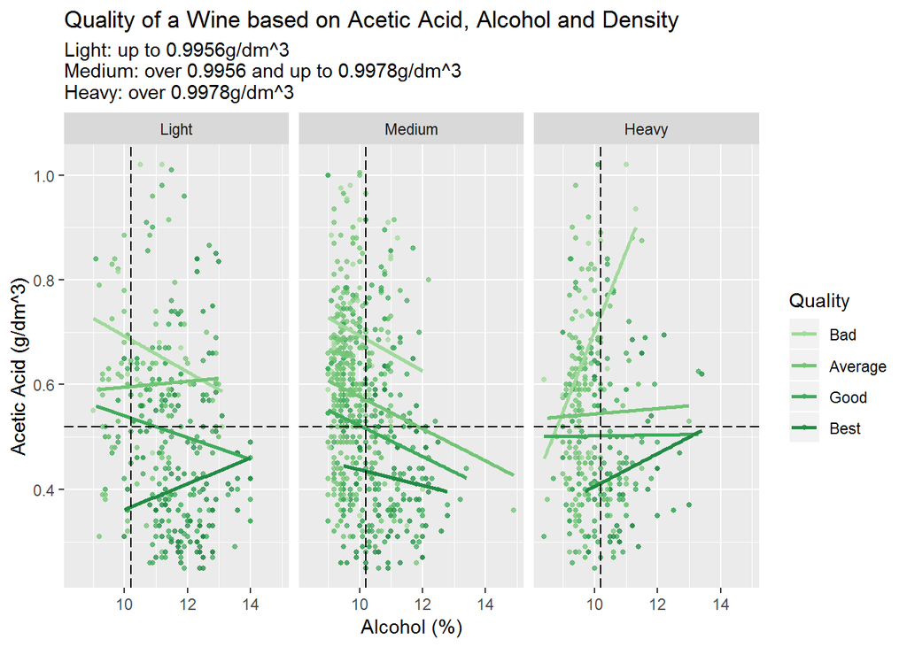

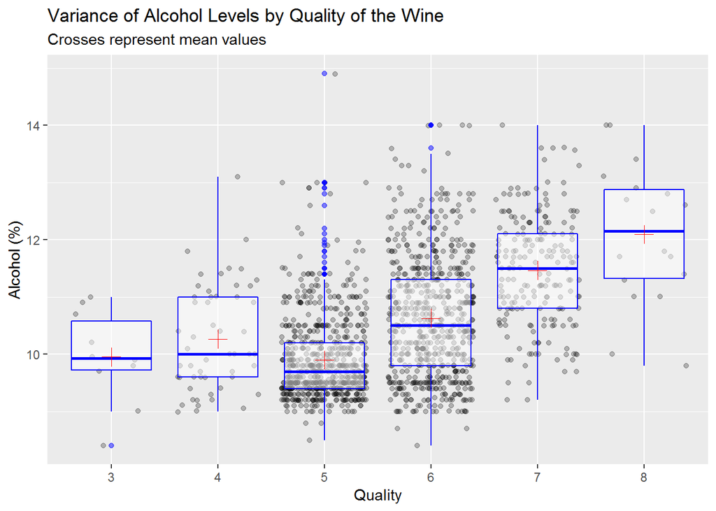

These boxplots are a great description of the most influential feature on regarding to the quality of a wine: alcohol. With the strongest correlation with quality, variance in the levels of alcohol between wines is what best separates the worst wines from the best ones.

# Reflection

This was my first solo attempt at an Exploratory Data Analysis. The data used consisted of physicochemical properties and quality of wines. Since my knowledge of wine was close to none, I as mostly looking at the data without much assumptions. The only thing that I thought I knew was that people use the density of the wine to describe its “body”, and that might be related to its quality.

As I went along with the exploration, I’ve discovered what features are more correlated with quality and if that correlation was positive or negative. I was surprised to discover that density was correlated, but not much. I had only one assumption and it turned out to be false!

The multivariate analysis was not easy to perform. Some of my first plots were not describing the data correctly, I used features on wrong axes, was not taking much out of them. Then, I decided to include the vertical and horizontal lines for the median values for each axis. After that, the information was clearer and the analysis was easier to make.

I’ve encountered two problems while doing this exploration. The first was that quality was the only naturally categorical feature. That limited my analysis at first, but I tried to go around that by creating two categorical features, derived from original features on the dataset. I think that, because of that, I was able to go further on my analysis. The second problem was the natural distribution of the data: most wines were of quality 5 or 6, with none below 3 or above 8. That was not a problem I could solve in any way I can think of. It wasn’t even a big problem, but it is necessary to address the results from this analysis with caution, as it could not be a good representation for other datasets of red wines.

Going further, some chemistry background knowledge could prove useful on trying to create more derived features. Maybe there is a relationship between the features on the dataset that I am not aware of. In reality, I’ve reserved most of the investigation to the three most correlated features and density (to address my only assumption). There could be much more hidden in the data I’m simply not yet experienced enough to unveil.